# Week 7: Industrial Sensors & Logic

EE0849 Introduction to Robotics

Basri Erdogan

# Part 1: Digital I/O Fundamentals

## The Robot’s Nervous System

[figure not shown]

Robots interact with the world through **digital I/O** — simple ON/OFF signals at 24V DC. Analog I/O also exists (force sensors, variable-speed drives) but digital covers most factory use cases.

## Digital Inputs: NPN vs PNP

[figure not shown]

**What robots sense:** part presence, position confirmation, safety status, machine states

When wiring sensors, match the type: **PNP** is standard in Europe/Asia (our lab), **NPN** in North America. Wrong type → input never triggers.

## Digital Outputs

[figure not shown]

**What robots control:** grippers, conveyors, indicator lights, other machines

| Type | Use case | Example |
| --- | --- | --- |
| **Transistor** | Fast DC switching | Gripper valve, 24V light |
| **Relay** | Isolation, AC/DC | 220V conveyor, separate power supply |
| **Triac** | AC loads, no wear | AC cooling fan, heater element |

Our FANUC has **transistor outputs** (24V DC) — sufficient for grippers and lights. For heavier loads, wire the DO to an external relay or contactor.

## FANUC I/O Architecture

| Type | Inputs | Outputs | Location |
| --- | --- | --- | --- |
| **Digital (DI/DO)** | DI[1]–DI[8] | DO[1]–DO[8] | Controller cabinet |
| **Robot (RI/RO)** | RI[1]–RI[8] | RO[1]–RO[8] | On the robot arm |
| **User (UI/UO)** | UI[1]–UI[18] | UO[1]–UO[10] | Safety / status |
| **Group (GI/GO)** | GI[1]–GI[N] | GO[1]–GO[N] | Multi-bit (integers) |

**Accessing I/O in TP Programs:**

- Read input: `IF DI[1]=ON, ...`
- Set output: `DO[1]=ON`
- Wait for input: `WAIT DI[2]=ON`

# Part 2: Industrial Sensors

## Proximity Sensors

[figure not shown]

Inductive

[figure not shown]

Capacitive

Barrel-shaped M12/M30, mounts flush in a bracket — you’ll see dozens on any factory line.

**Inductive** — detects **metal only**

- “Is the steel bolt in the fixture?”
- Range: 1–30 mm, response: <1 ms
- Cheap, fast, very reliable

**Capacitive** — detects **any material** (metal, plastic, liquid, wood)

- Glue level in a reservoir, plastic cap presence
- Range: 1–25 mm
- Sensitive to environment (humidity, dust)

## Photoelectric Sensors

All use light (infrared/visible) to detect objects at a distance.

[figure not shown]

Through-beam

[figure not shown]

Retro-reflective

[figure not shown]

Diffuse

| Type | Use case | Range |
| --- | --- | --- |
| **Through-Beam** | Box counting, gate | up to 30 m |
| **Retro-Reflective** | Pallet detection | 3–10 m |
| **Diffuse** | PCB on tray? | 10–500 mm |

## Mechanical & Pressure Sensors

[figure not shown]

Limit switch

[figure not shown]

Vacuum switch

- **Limit Switch:** Physical contact — object pushes lever, toggles contacts (NO↔︎NC). Confirms clamp closed, end-of-travel. Nearly indestructible.
- **Pressure Switch:** Monitors pneumatic line pressure — if pressure drops, DI goes OFF → fault detected.
- **Vacuum Switch:** Measures suction level at the gripper. If vacuum is below threshold → part not sealed → abort pick.

## Other Sensor Types

Beyond the four main types, you will encounter these in robotics:

- **Encoders** — Inside every servo motor; measure joint position and velocity. The robot already uses these — they’re how the controller knows the current joint angles
- **Force/Torque (F/T)** — Mounted at the wrist; measures 6-axis contact forces. Used for assembly, polishing, and collision detection
- **Vision / Camera** — 2D or 3D imaging for part localization, inspection, and guidance. We will use iRVision in a later lab
- **Ultrasonic** — Distance measurement using sound waves. Used for bin fill level, object distance (1 cm – several meters)
- **Laser distance / ToF** — Precise ranging and profiling (e.g., part height inspection, surface scanning)
- **Pressure / Flow** — Confirms pneumatic gripper pressure, coolant flow, vacuum level

## Sensor Selection Guide

| Sensor Type | Detects | Range | Speed | Cost |
| --- | --- | --- | --- | --- |
| Inductive | Metal only | Short | Fast | Low |
| Capacitive | Any material | Short | Medium | Medium |
| Photoelectric | Any (line of sight) | Long | Fast | Medium |
| Limit Switch | Physical contact | Contact | Slow | Low |

**Selection Criteria:**

1. What material? (Metal → Inductive)
2. What range? (Long → Photoelectric)
3. Environment? (Dirty → Inductive/Limit)
4. Speed required? (Fast → Inductive/Photo)

## Quick Check: Sensor Selection

**Scenario:** Your robot cell needs to detect:

1. Steel bolts arriving on a conveyor (range ~5mm)
2. A cardboard box at a loading station (range ~2m)
3. Whether the gripper jaws are fully closed

## Real Sensors for the FANUC ER-4iA

Any **3-wire PNP sensor with 24V DC output** wires directly to DI[1]–DI[8].

| Need | Sensor Type | Example Models |
| --- | --- | --- |
| Metal part in fixture | Inductive (M8/M12 barrel) | Omron E2E, Sick IME, IFM IF5 |
| Any-material detection | Diffuse photoelectric | Omron E3Z, Sick W4, Banner QS18 |
| Gripper closed confirm | Micro limit switch | Omron D4MC, Honeywell V15 |
| Suction grip confirm | Vacuum switch | SMC ZSE30, Festo VPEV |
| Cell entry detection | Safety light curtain | Sick C4000, Omron F3SG |

For a basic pick-and-place cell you typically need just **2–3 sensors**: one for part presence (inductive), one for grip confirm (pressure/vacuum switch), and optionally one at the place station (diffuse photoelectric).

# Part 3: Safety Systems

## Why Safety is Critical

[figure not shown]

Safety is **not optional** — it’s regulated by law (ISO 10218, ANSI/RIA 15.06, EN ISO 13849). Every robot cell must address these four hazard categories through layered protection.

## Safety Circuit Architecture

[figure not shown]

The diagram says it all: every device is NC and wired in **series**. Any break → robot stops. No software can override this chain.

## Safety Devices

| Device | How It Works | Trigger |
| --- | --- | --- |
| **E-Stop** | Red mushroom button, hardwired | Pressed → cuts power |
| **Deadman** | 3-position enable switch | Release or squeeze = stop |
| **Light Curtain** | IR beam array across opening | Body breaks beam → stop |
| **Safety Mat** | Pressure-sensitive floor | Person steps on → stop |

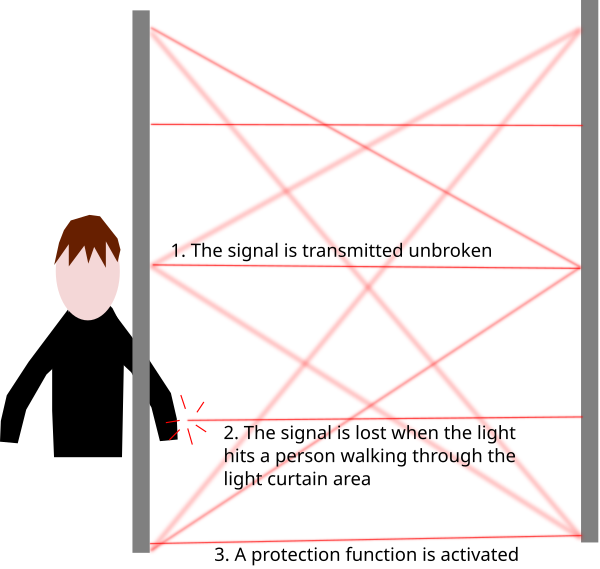

Light curtain: person breaks beams → protection activated

## FANUC Operating Modes

| Mode | Speed | Deadman | Use |
| --- | --- | --- | --- |
| **T1** (Teach) | ≤ 250 mm/s | Must hold | Teaching positions, testing |
| **T2** (Test) | Full speed | Must hold | Full-speed verification |
| **AUTO** (Run) | Full speed | Not used | Production, cycle start via UI[6] |

- **T1 → T2 → AUTO** progression: always test at slow speed first
- Mode selected by key switch on controller
- Deadman switch: release OR squeeze fully = immediate stop

# Part 4: Motion & Position Fundamentals

## Motion Types

| Type | Syntax | Path Shape | Speed Units | When to Use |
| --- | --- | --- | --- | --- |
| **Joint (J)** | `J P[1] 100% FINE` | Curved (joint space) | `%` of max (1–100) | Large free moves, fastest |
| **Linear (L)** | `L P[2] 500mm/sec FINE` | Straight line | `mm/sec`, `cm/min` | Near workpieces, precise |
| **Circular (C)** | `C P[3] P[4] 200mm/sec FINE` | Arc through via point | `mm/sec`, `cm/min` | Curved paths (welding, sealing) |
| **Arc (A)** | `A P[5] 200mm/sec FINE` | Chained circular arcs | `mm/sec`, `cm/min` | Continuous curves (3+ arc segments) |

- **J** moves all joints simultaneously — path is unpredictable in Cartesian space
- **L** and **C** control the TCP path — the controller interpolates in Cartesian space
- **A** requires 3+ consecutive arc instructions to define the full curve

## Speed Control

| Motion | Unit | Range | Example |
| --- | --- | --- | --- |
| Joint (J) | `%` | 1–100 | `J P[1] 50% FINE` |
| Linear (L, C, A) | `mm/sec` | 1–2000 | `L P[2] 800mm/sec CNT50` |
| Linear (L, C, A) | `cm/min` | 1–12000 | `L P[2] 4800cm/min CNT50` |
| Rotation | `deg/sec` | 1–272 | `L P[3] 90deg/sec FINE` |
| Any | `sec` | 0.1–3200 | `L P[4] 2.0sec FINE` |

**Override:** limits all motion to a percentage of programmed speed:

```
OVERRIDE=50% ;     ! All moves run at half speed
OVERRIDE=R[10]% ;  ! Speed from register
```

## Termination Types: FINE vs CNT

[figure not shown]

```
L P[1] 100mm/sec FINE    ; Stop exactly at point
L P[2] 500mm/sec CNT50   ; Blend through point
```

**Rule of thumb:** `FINE` at pick/place, `CNT` for transit.

- CNT0 = closest to point without stopping
- CNT100 = maximum smoothing (fastest, least accurate)
- Blending is faster but the robot won’t hit the exact waypoint

## Position Data

**Cartesian representation:**

```
UF:2  UT:1
X:  1500.374  W:  10.000
Y: -342.992  P:  20.000
Z:  956.895  R:  40.000
CONF: N, U, T, 0, 0, 0
```

- **X, Y, Z** — TCP position (mm)
- **W, P, R** — orientation (degrees)
- **CONF** — robot configuration

**Joint representation:**

```
J1:   45.000   J4:    0.000
J2:  -30.000   J5:  -90.000
J3:   60.000   J6:  180.000
```

- Each value is one joint angle (degrees)
- No ambiguity — one set of joint values = one pose
- Used internally for J motion

## Robot Configuration

The same Cartesian pose (X,Y,Z,W,P,R) can be reached with **multiple joint solutions** — the configuration string resolves this ambiguity.

| Flag | Options | Meaning |
| --- | --- | --- |
| **Wrist** | FLIP / NOFLIP | Wrist orientation (J5 sign) |
| **Arm** | UP / DOWN | Elbow above or below shoulder line |
| **Reach** | FRONT / BACK | Robot reaching forward or backward |
| **Turn** | –1, 0, 1 | Which 360° sector each axis is in |

```
CONF: N, U, T, 0, 0, 0
       │  │  │  │  │  └─ J6 turn number
       │  │  │  │  └──── J5 turn number
       │  │  │  └─────── J4 turn number
       │  │  └────────── FRONT (T) or BACK (B)
       │  └───────────── UP (U) or DOWN (D)
       └──────────────── NOFLIP (N) or FLIP (F)
```

This is the IK solution selector — same target, different arm pose.

## P[i] vs PR[i]

|  | **P[i]** — Position Variable | **PR[i]** — Position Register |
| --- | --- | --- |
| **Scope** | Local to one program | Global (shared across all programs) |
| **Typical use** | Taught waypoints | Computed positions, offsets |
| **How set** | Teach pendant (jog & record) | TP code or direct entry |
| **Count** | Up to ~5000 per program | PR[1]–PR[100] |

```
J P[1:Home] 100% FINE ;         ! Local taught position
L PR[1:Offset_Pos] 500mm/sec FINE ;  ! Global computed position
PR[1]=P[1] ;                    ! Copy P into PR
```

**When to use which:**

- **P[i]** for fixed, taught points (home, pick, place)
- **PR[i]** for positions calculated at runtime (offsets, patterns, sensor-based corrections)

# Part 5: Program Logic

## TP Program Structure

```
/PROG PICK_PLACE
/ATTR
OWNER    = ;
COMMENT  = "Simple Pick and Place";
/MN
   1:  ! Initialize ;
   2:  DO[1:Gripper]=OFF ;
   3:  J P[1:Home] 100% FINE ;
   4:  ! Pick sequence ;
   5:  L P[2:Pick_App] 500mm/sec FINE ;
   6:  L P[3:Pick] 100mm/sec FINE ;
   7:  DO[1:Gripper]=ON ;
   8:  WAIT  .50(sec) ;
   9:  L P[2:Pick_App] 500mm/sec FINE ;
  10:  ! Place sequence ;
  11:  L P[4:Place_App] 500mm/sec FINE ;
  12:  L P[5:Place] 100mm/sec FINE ;
  13:  DO[1:Gripper]=OFF ;
  14:  WAIT  .30(sec) ;
  15:  L P[4:Place_App] 500mm/sec FINE ;
  16:  J P[1:Home] 100% FINE ;
/END
```

## Conditional Logic

**IF/THEN/ELSE**

```
IF DI[1]=ON, JMP LBL[10] ;
! DI[1] is OFF, do this:
DO[2]=ON ;
JMP LBL[20] ;
LBL[10] ;
! DI[1] is ON, do this:
DO[3]=ON ;
LBL[20] ;
```

**SELECT (Case Statement)**

```
SELECT R[1]=1, JMP LBL[1] ;
       =2, JMP LBL[2] ;
       =3, JMP LBL[3] ;
       ELSE, JMP LBL[99] ;
```

**Pendant: [INST] button**

| Instruction | Path |
| --- | --- |
| IF (register) | 3 IF/SELECT → 1 |
| IF (input) | 3 IF/SELECT → 2 |
| SELECT | 3 IF/SELECT → 3 |
| Label | 5 JMP/LBL → 2 |
| Jump | 5 JMP/LBL → 1 |

## Loops and Waiting

**FOR Loop**

```
FOR R[1]=1 TO 10 ;
  ! Repeat 10 times
  L P[1] 500mm/sec CNT100 ;
  L P[2] 500mm/sec CNT100 ;
ENDFOR ;
```

**WAIT Instructions**

```
WAIT  1.00(sec) ;           ! Wait 1 second
WAIT DI[1]=ON ;             ! Wait for input
WAIT DI[1]=ON TIMEOUT,LBL[99] ;
```

**Labels and Jumps**

```
LBL[1] ;
  ! Do something
  IF R[1]<10, JMP LBL[1] ;  ! Loop back
```

**Pendant: [INST] button**

| Instruction | Path |
| --- | --- |
| FOR | page 3 → 1 FOR/ENDFOR |
| ENDFOR | page 3 → 1 FOR/ENDFOR |
| WAIT (time) | 4 WAIT |
| WAIT (condition) | 4 WAIT |
| I/O (DO) | 2 I/O |
| Registers | 1 Registers |

## Loop Patterns: WHILE and DO-WHILE

FANUC TP has no native `WHILE` keyword — build it with `LBL`/`IF`/`JMP`:

**WHILE pattern** (check before body):

```
LBL[1] ;
  IF R[1]>=10, JMP LBL[2] ;  ! exit condition
  ! --- loop body ---
  L PR[1] 500mm/sec FINE ;
  R[1]=R[1]+1 ;
  JMP LBL[1] ;                ! loop back
LBL[2] ;
```

Runs **zero or more** times.

**DO-WHILE pattern** (check after body):

```
LBL[1] ;
  ! --- loop body ---
  WAIT DI[1]=ON ;
  CALL PROCESS_PART ;
  R[1]=R[1]+1 ;
  IF R[1]<10, JMP LBL[1] ;   ! loop back
```

Runs **at least once**.

## Registers and Data

**Registers (R[ ])**

```
R[1]=0 ;              ! Set to zero
R[1]=R[1]+1 ;         ! Increment
IF R[1]>10, JMP LBL[5] ;
```

**Position Registers (PR[ ])**

```
PR[1]=P[1] ;          ! Copy position
PR[1,1]=100.0 ;       ! Set X component
L PR[1] 500mm/sec FINE ; ! Move to PR
```

**Using Math**

```
R[3]=R[1]+R[2] ;      ! Addition
R[4]=R[1]*2 ;         ! Multiplication
R[5]=SQRT[R[1]] ;     ! Square root
```

**Pulse Output** (single timed pulse, useful for signaling):

```
DO[2:Done]=PULSE,0.5sec ;
```

## Frames: UTOOL and UFRAME

**User Frame (UFRAME)** — where is the work?

- Defines the workpiece coordinate system
- All taught positions are relative to it
- Change UFRAME = all positions shift together

```
UFRAME_NUM=2 ;   ! Switch to frame 2
```

*If your part moves to a new fixture, just re-teach the frame — not every point.*

**Tool Frame (UTOOL)** — what’s on the wrist?

- Defines the tool center point (TCP)
- Calibrate once per tool/gripper
- Affects all motion and position display

```
UTOOL_NUM=3 ;     ! Switch to tool 3
```

*Wrong UTOOL = robot goes to wrong place. Always verify which tool is active before teaching.*

## Subroutines with CALL

Break programs into reusable parts — just like functions in Python:

```
/PROG MAIN
   1:  CALL PICK ;         ! Run the PICK subprogram
   2:  CALL PLACE ;        ! Run the PLACE subprogram
   3:  JMP LBL[1] ;        ! Loop
/END
```

```
/PROG PICK
   1:  L P[1:Approach] 500mm/sec FINE ;
   2:  L P[2:Grasp] 100mm/sec FINE ;
   3:  DO[1:Gripper]=ON ;
   4:  WAIT  .30(sec) ;
   5:  L P[1:Approach] 500mm/sec FINE ;
/END
```

Use `CALL` to keep programs short and reusable — just like functions in code.

## Position Register Math (Offsets)

PR components: `PR[n,1]=X`, `PR[n,2]=Y`, `PR[n,3]=Z`

**Offset a position by 50mm in X:**

```
PR[10]=P[1:Base] ;        ! Copy base position
PR[10,1]=PR[10,1]+50.0 ;  ! Shift X by 50mm
L PR[10] 200mm/sec FINE ;  ! Move to offset position
```

**3×3 grid palletizing pattern:**

```
PR[10]=P[1:Corner] ;        ! Grid origin
FOR R[1]=0 TO 2 ;
  FOR R[2]=0 TO 2 ;
    PR[10,1]=P[1:Corner,1]+R[2]*50 ;  ! X offset
    PR[10,2]=P[1:Corner,2]+R[1]*50 ;  ! Y offset
    L PR[10] 300mm/sec FINE ;
    CALL PLACE ;
  ENDFOR ;
ENDFOR ;
```

## Built-in Offset Instructions

Instead of manually computing PR math, FANUC provides dedicated offset instructions:

**General Offset** (relative to User Frame):

```
! Set offset condition
OFFSET CONDITION PR[10] ;
! Move with offset applied
L P[1] 500mm/sec FINE Offset ;

! Or apply directly:
L P[1] 500mm/sec FINE Offset,PR[10] ;
```

Shifts the target point by PR[10] values in the **active User Frame** directions.

**Tool Offset** (relative to Tool Frame):

```
! Set offset condition
TOOL_OFFSET CONDITION PR[20] ;
! Move with tool offset applied
L P[1] 500mm/sec FINE Tool_Offset ;

! Or apply directly:
L P[1] 500mm/sec FINE Tool_Offset,PR[20] ;
```

Shifts along the **tool axes** — useful for approach/retract along the tool Z.

**Key difference:** General Offset shifts in world/user frame directions. Tool Offset shifts in the tool’s own coordinate system (e.g., approach 50mm above a surface along the gripper axis regardless of orientation).

# Part 6: Practical Applications

## Pick and Place with Sensor Check

```
/PROG PICK_WITH_CHECK
   1:  J P[1:Home] 100% FINE ;
   2:  LBL[1] ;
   3:  ! Wait for part present
   4:  WAIT DI[1:Part_Sensor]=ON ;
   5:  ! Pick sequence
   6:  L P[2:Pick_App] 500mm/sec FINE ;
   7:  L P[3:Pick] 100mm/sec FINE ;
   8:  DO[1:Gripper]=ON ;
   9:  WAIT  .30(sec) ;
  10:  ! Verify grip
  11:  IF DI[2:Grip_Confirm]=OFF, JMP LBL[99] ;
  12:  L P[2:Pick_App] 500mm/sec FINE ;
  13:  ! Place sequence
  14:  L P[4:Place_App] 500mm/sec CNT50 ;
  15:  L P[5:Place] 100mm/sec FINE ;
  16:  DO[1:Gripper]=OFF ;
  17:  WAIT  .20(sec) ;
  18:  L P[4:Place_App] 500mm/sec FINE ;
  19:  JMP LBL[1] ;  ! Loop forever
  20:  LBL[99] ;
  21:  ! Error: grip failed
  22:  DO[3:Error_Light]=ON ;
  23:  PAUSE ;
/END
```

## I/O Handshaking with External Device

[figure not shown]

The diagram shows the protocol. In TP code:

```
DO[1:Robot_Ready]=ON ;              ! 1. Signal "ready"
WAIT DI[1:Part_Ready]=ON ;          ! 2. Wait for conveyor
DO[1:Robot_Ready]=OFF ;             ! 3. Acknowledge
! ... pick operation ...
DO[2:Pick_Done]=PULSE,0.5sec ;      ! 4. Signal "done"
```

## Debugging I/O & Common Mistakes

**On the Teach Pendant:**

1. **I/O Screen**: MENU → I/O → Digital
   - View all DI/DO states
   - Force outputs ON/OFF (in manual mode)
2. **Status Screen**: Shows active I/O

**Common I/O Issues:**

| Symptom | Likely Cause |
| --- | --- |
| Input always OFF | Wiring, sensor fault, wrong type |
| Input always ON | Stuck sensor, wrong NO/NC logic |
| Output no effect | Load not connected, fuse blown |
| Intermittent | Loose connection, noise |

**Common TP Programming Mistakes:**

- Forgetting `WAIT` after gripper ON/OFF — gripper hasn’t closed yet when robot moves
- Using `J` motion near workpiece — unpredictable path may collide
- Missing `FINE` at pick/place — robot blends past the target
- Wrong sensor logic — NO sensor reads opposite of what you expect
- No grip confirmation — robot moves with no part

## Summary

**Key Concepts:**

1. **Digital I/O**: The interface between robot and world
2. **Sensors**: Inductive, photoelectric, mechanical - choose by application
3. **Safety**: Layered protection, fail-safe design
4. **Program Logic**: Motion commands, conditionals, loops

**Next Week:**

- Week 8: Digital Twinning & Calibration
- Comparing simulation to reality
- Measuring and correcting errors

## Exit Ticket

**Scenario:** You need to write a FANUC TP program that:

- Waits for a part sensor (DI[1]) to turn ON
- Moves to the pick position with Joint motion
- Closes the gripper (DO[1]=ON) and waits 0.5 seconds
- Moves to the place position with Linear motion
- Opens the gripper (DO[1]=OFF)

Write the TP program (5-7 lines).

## Exit Ticket: Solution

```
   1: WAIT DI[1:Part_Ready]=ON ;
   2: J P[1] 100% FINE ;
   3: DO[1:Gripper]=ON ;
   4: WAIT  .50(sec) ;
   5: L P[2] 200mm/sec FINE ;
   6: DO[1:Gripper]=OFF ;
   7: WAIT  .50(sec) ;
```

**Key points:**

- WAIT for sensor *before* moving (don’t pick air!)
- Joint (J) for fast travel to pick, Linear (L) for precise place
- FINE termination at pick/place (must stop exactly)
- WAIT after gripper commands (mechanical delay)

## Questions?

[figure not shown]

**Lab this week: Teach Pendant Programming!**